# Project 6 - Support Ticket Categorization - Wes Henderson

## **Problem Statement**

### Business Context

In today's dynamic business landscape, organizations are increasingly recognizing the pivotal role customer feedback plays in shaping the trajectory of their products and services. The ability to swiftly and effectively respond to customer input not only fosters enhanced customer experiences but also serves as a catalyst for growth, prolonged customer engagement, and the nurturing of lifetime value relationships. As a dedicated Product Manager or Product Analyst, staying attuned to the voice of your customers is not just a best practice; it's a strategic imperative.

While your organization may be inundated with a wealth of customer-generated feedback and support tickets, your role entails much more than just processing these inputs. To make your efforts in managing customer experience and expectations truly impactful, you need a structured approach – a method that allows you to discern the most pressing issues, set priorities, and allocate resources judiciously. One of the most effective strategies at your disposal is to harness the power of Support Ticket Categorization.

### Objective

Develop an advanced support ticket categorization system that accurately classifies incoming tickets, assigns relevant tags based on their content, implements mechanisms and generate the first response based on the sentiment for prioritizing tickets for prompt resolution.

## **Installing and Importing Necessary Libraries and Dependencies**

```python
# Function to download the model from the Hugging Face model hub
from huggingface_hub import hf_hub_download

# Importing the Llama class from the llama_cpp module
from llama_cpp import Llama

# Importing the json module
import json

# for loading and manipulating data
import pandas as pd

# for time computations
import time
import re

# data visualization
import matplotlib.pyplot as plt
from collections import Counter
from wordcloud import WordCloud
import seaborn as sns
```

## **Loading the Data**

```python
# Complete the code to read the CSV file.
data = pd.read_csv("Support_ticket_text_data_mid_term.csv")
```

## **Data Overview**

### Checking the first 5 rows of the data

```python
# Complete the code to check the first 5 rows of the data
data.head()
```

|  | support_tick_id | support_ticket_text |
| --- | --- | --- |
| 0 | ST2023-006 | My internet connection has significantly slowe... |
| 1 | ST2023-007 | Urgent help required! My laptop refuses to sta... |
| 2 | ST2023-008 | I've accidentally deleted essential work docum... |
| 3 | ST2023-009 | Despite being in close proximity to my Wi-Fi r... |
| 4 | ST2023-010 | My smartphone battery is draining rapidly, eve... |

```python
data.info()
```

```
<class 'pandas.core.frame.DataFrame'>
RangeIndex: 21 entries, 0 to 20
Data columns (total 2 columns):
 #   Column               Non-Null Count  Dtype
---  ------               --------------  -----
 0   support_tick_id      21 non-null     object
 1   support_ticket_text  21 non-null     object
dtypes: object(2)
memory usage: 468.0+ bytes
```

### Checking the shape of the data

```python
# Complete the code to check the shape of the data
data.shape
```

```
(21, 2)
```

### Checking the missing values in the data

```python
# Complete the code to check for missing values in the data
data.isnull().sum()
```

```
support_tick_id        0
support_ticket_text    0
dtype: int64
```

**Observations**

- The initial dataset has 21 rows and 2 columns
- All data is of the dtype object
- No missing values are within the dataset

## **Model Building**

### Loading the model

```python
model_name_or_path = "TheBloke/Mistral-7B-Instruct-v0.2-GGUF"
model_basename = "mistral-7b-instruct-v0.2.Q6_K.gguf"

model_path = hf_hub_download(
    repo_id=model_name_or_path, # Complete the code to mention the repo_id
    filename=model_basename # Complete the code to mention the
)
```

```python
# uncomment and run the following code in case GPU is being used
llm = Llama(
     model_path=model_path,
     n_ctx=1024, # Context window
 )
```

[output not shown]

[output cut: 49 more lines]

[output not shown]

### Utility functions

```python
# Function to parse JSON data and extract key-value pairs
def extract_json_data(json_str):
    try:
        data_dict = json.loads(json_str)
        return data_dict
    except json.JSONDecodeError as e:
        print(f"Error parsing JSON: {e}")
        return {}
```

## **Create structured output**

Rather than complete each task individually, I'm going to create a function that will return all necessary values from the `llama` response, rather than look for each individually.

```python
def llama_response(support_ticket):
    # System message
    system_message = """<s>[INST]You are an intelligent assistant tasked with analyzing individual customer IT support tickets. Your job is to categorize the ticket, assign relevant tags, determine the priority level based on the provided criteria, estimate the time required to resolve the issue, and provide a draft response.
    Extract only the following information from the support ticket text to output JSON representation with the below headers. Ensure the JSON format includes key-value pairs for each detail.
    The output should be in the following format:
    {
    "Category": "Classify the support ticket using only one of the following categories: Application Support, Hardware, Network, Security, Data Issues.",
    "Tags": "Add tags that specify the area of the issue to help further classify the ticket",
    "Priority": "Assign the priority level based on the following criteria as one of the following: Low, Medium, High",
    "ETA": "Provide the suggested resolution time in hours.",
    "Draft Response": "Craft a brief response based on the priority. For example, if the priority is high, respond with urgency; if medium, provide a standard response; if low, explain that other tickets will take priority but attention will be given as soon as possible"
    }
    [/INST]
    """
    # Combine system message and support ticket text
    prompt = f"{system_message}\n{support_ticket}"

    try:
        # Generate a response from the LLaMA model
        response = llm(
            prompt=prompt,
            max_tokens=250,
            temperature=0,                   # At zero to ensure deterministic output
            top_p=0.95,                      # Balance quality and diversity
            repeat_penalty=1.1,              # Penalize repetition to some extent
            top_k=50,                        # Consider the top 50 tokens
            stop=['</s>', '[INST]'],         # Stop generating at the system message
            echo=False                       # Do not include the prompt in the response
        )

        # Extract and return the response text
        response_text = response["choices"][0]["text"].strip()

        # Log the raw response for debugging
        print("Raw response:", response_text)

        # Isolate the JSON string from the response text using regular expressions
        match = re.search(r'\{.*?\}', response_text, re.DOTALL)
        if match:
            response_text = match.group()
        else:
            response_text = '{"Error": "Unable to parse response from model."}'

    except Exception as e:
        response_text = f'{{"Error": "Exception occurred: {str(e)}"}}'

    return response_text
```

```python
# creating a copy of the data
data_1 = data.copy()
```

```python
start = time.time()
data_1['model_response'] = data_1['support_ticket_text'].apply(lambda x: llama_response(x))
end = time.time()
```

[output not shown]

```
Raw response: (Note: I am using a wired connection)

{
  "Category": "Network",
  "Tags": ["Connectivity", "Internet", "Wired Connection"],
  "Priority": "High",
  "ETA": "4 hours",
  "Draft Response": "We understand the urgency of your situation and will prioritize your network connectivity issue. Our team will work diligently to diagnose and resolve the cause of your slow internet connection within 4 hours."
}
```

[output not shown]

```
Raw response: .

{
  "Category": "Hardware",
  "Tags": ["Laptop", "Startup"],
  "Priority": "High",
  "ETA": "4 hours",
  "Draft Response": "We understand the urgency of your situation and will prioritize your hardware issue. Our team will work diligently to diagnose and resolve your laptop's startup problem within 4 hours."
}
```

[output not shown]

```
Raw response: {
"Category": "Data Issues",
"Tags": ["Data Loss"],
"Priority": "High",
"ETA": "8 hours",
"Draft Response": "We understand the urgency of your situation and will prioritize your data recovery request. Our team will work diligently to help you recover your lost documents as soon as possible. In the meantime, please avoid using your device to prevent any potential data overwriting."
}
```

[output not shown]

```
Raw response: (Assuming this is a single support ticket)

{
  "Category": "Network",
  "Tags": ["Wi-Fi", "Signal Strength"],
  "Priority": "Medium",
  "ETA": "Within 2 business days",
  "Draft Response": "Hello! I understand that you're experiencing weak Wi-Fi signal strength at your location. I'd be happy to help you troubleshoot this issue. In the meantime, you may try moving your device closer to the router or restarting both your device and router. If these steps don't help, …
}
```

[output not shown]

```
Raw response: I have tried restarting my device and calibrating the battery settings but the problem persists.

{
  "Category": "Hardware",
  "Tags": ["Battery"],
  "Priority": "Medium",
  "ETA": "24 hours",
  "Draft Response": "Hello! I'm sorry to hear that your smartphone battery is draining faster than expected. I understand that this can be frustrating. I suggest checking for any battery-draining apps or settings that might be causing this issue. Restarting your device and calibrating the battery se…
}
```

[output not shown]

```
Raw response: {
        "Category": "Security",
        "Tags": ["Account Access", "Password Reset"],
        "Priority": "High",
        "ETA": "1 hour",
        "Draft Response": "Dear Valued Customer,\n\nWe're sorry for any inconvenience you've experienced in accessing your online banking account. To ensure your security, we'll need to verify your identity before resetting your password. Please provide us with your account number, full name, and th…
    }
```

[output not shown]

```
Raw response: (Assuming this is a single support ticket)

{
  "Category": "Application Support",
  "Tags": ["Performance", "Productivity"],
  "Priority": "High",
  "ETA": "4 hours",
  "Draft Response": "We understand the urgency of your situation and will prioritize your request for application optimization. Our team will work diligently to identify and address any performance issues affecting your system within 4 hours."
}
```

[output not shown]

```
Raw response: {
        "Category": "Hardware",
        "Tags": ["Hardware Malfunction", "Blue Screen Error"],
        "Priority": "High",
        "ETA": "2 hours",
        "Draft Response": "We understand that you're experiencing frequent crashes due to a blue screen error, which indicates a hardware issue. We'll prioritize this ticket and aim to have a resolution within 2 hours. In the meantime, please ensure your system is powered off to prevent further dama…
    }
```

[output not shown]

```
Raw response: (Assuming this is a single support ticket)

{
  "Category": "Data Issues",
  "Tags": ["Data Recovery", "External Hard Drive"],
  "Priority": "High",
  "ETA": "4-6 hours",
  "Draft Response": "We understand the urgency of your situation and will prioritize your data recovery request. Our team will work diligently to recover your vital data from your external hard drive as soon as possible."
}
```

[output not shown]

```
Raw response: {
"Category": "Hardware",
"Tags": ["Graphics Card"],
"Priority": "High",
"ETA": "4 hours",
"Draft Response": "Hello! I'm sorry for any inconvenience you're experiencing with your gaming laptop's graphics card performance. I understand that this can be frustrating, especially when trying to enjoy your favorite games. I'll do my best to help you diagnose and resolve this issue as soon as po…
}
```

[output not shown]

```
Raw response: {
"Category": "Data Issues",
"Tags": ["Data Recovery"],
"Priority": "High",
"ETA": "8 hours",
"Draft Response": "I'm sorry for your data loss. I understand the urgency of your situation. I will guide you through the data recovery process as soon as possible. Please do not write any new data to the USB drive until we begin the recovery process."
}
```

[output not shown]

```
Raw response: {
  "Category": "Hardware",
  "Tags": ["Display"],
  "Priority": "High",
  "ETA": "2 hours",
  "Draft Response": "We understand that your screen has gone black and you require immediate assistance. Our team will prioritize this issue and work towards resolving it as soon as possible. Please ensure your computer is connected to power and try a few basic troubleshooting steps before we begin …
}
```

[output not shown]

```
Raw response: {
  "Category": "Hardware",
  "Tags": ["Hardware Damage"],
  "Priority": "High",
  "ETA": "48 hours for assessment and data recovery (if possible)",
  "Draft Response": "We're sorry for your hardware issue. Due to the nature of your problem, we prioritize this ticket as high. Our team will assess the damage as soon as possible and will keep you updated on any progress regarding data recovery."
}
```

[output not shown]

```
Raw response: {
    "Category": "Hardware",
    "Tags": ["Data Recovery", "Hardware Damage"],
    "Priority": "High",
    "ETA": "4-6 hours",
    "Draft Response": "We understand the urgency of your situation and will prioritize your request for data recovery from your physically damaged USB flash drive. Our team will work diligently to recover your critical files as soon as possible."
}
```

[output not shown]

```
Raw response: {
"Category": "Hardware",
"Tags": ["Touchpad"],
"Priority": "High",
"ETA": "2-4 hours",
"Draft Response": "I'm sorry for the inconvenience you're experiencing with your laptop's touchpad. I understand this can significantly impact your productivity. I'll prioritize this high-priority hardware issue and aim to have it resolved within 2-4 hours."
}
```

[output not shown]

```
Raw response: (Analysis)

{
"Category": "Network",
"Tags": ["Connectivity", "Internet"],
"Priority": "High",
"ETA": "4 hours",
"Draft Response": "We understand that you're experiencing frequent internet connection drops which can significantly impact your work. Our team will prioritize this issue and work towards resolving it as soon as possible. We aim to have your connection stabilized within 4 hours."
}
```

[output not shown]

```
Raw response: (Assume this is the support ticket text)

{
"Category": "Network",
"Tags": ["Wi-Fi", "Connectivity"],
"Priority": "High",
"ETA": "4 hours",
"Draft Response": "We understand that your Wi-Fi connection is currently affecting your work productivity. Our team will prioritize this issue and aim to have it resolved within 4 hours. In the meantime, you may try restarting your router or moving closer to it for better signal strength."
}
```

[output not shown]

```
Raw response: {
    "Category": "Data Issues",
    "Tags": ["Data Recovery"],
    "Priority": "High",
    "ETA": "8 hours",
    "Draft Response": "We understand the urgency of your situation and will prioritize your data recovery request. Our team will begin working on this as soon as possible. In the meantime, please avoid using the USB drive to prevent further data loss."
    }
```

[output not shown]

```
Raw response: {
"Category": "Hardware",
"Tags": ["Storage Devices"],
"Priority": "High",
"ETA": "4 hours",
"Draft Response": "We understand the urgency of your situation and will prioritize your hardware issue. Our team will work diligently to recover your vital data as soon as possible."
}
```

[output not shown]

```
Raw response: {
"Category": "Network",
"Tags": ["Connectivity", "Internet", "Disconnections", "Slow Speed"],
"Priority": "High",
"ETA": "4 hours",
"Draft Response": "We understand the urgency of your situation and will prioritize your network connectivity issue. Our team will work diligently to diagnose and resolve your disconnections and slow internet speed as soon as possible. We anticipate resolving this within 4 hours."
}
```

[output not shown]

```
Raw response: {
"Category": "Data Issues",
"Tags": ["Software Compatibility", "Data Loss"],
"Priority": "High",
"ETA": "4 hours",
"Draft Response": "Dear Valued Customer,\n\nThank you for bringing this complex issue to our attention. We understand that the unexpected behavior of certain applications and data loss have caused significant disruptions to your daily tasks.\n\nOur team of experts will prioritize this high-priority …
}
```

```python
total_time = end - start
minutes = total_time // 60
seconds = total_time % 60

print(f"Time taken: {minutes} minutes and {seconds} seconds")
```

```
Time taken: 7.0 minutes and 55.0869357585907 seconds
```

```python
# Write the code to check the first five rows of the data to confirm whether the new column has been added
data_1.head()
```

|  | support_tick_id | support_ticket_text | model_response |
| --- | --- | --- | --- |
| 0 | ST2023-006 | My internet connection has significantly slowe... | {\n "Category": "Network",\n "Tags": ["Conne... |
| 1 | ST2023-007 | Urgent help required! My laptop refuses to sta... | {\n "Category": "Hardware",\n "Tags": ["Lapt... |
| 2 | ST2023-008 | I've accidentally deleted essential work docum... | {\n"Category": "Data Issues",\n"Tags": ["Data ... |
| 3 | ST2023-009 | Despite being in close proximity to my Wi-Fi r... | {\n "Category": "Network",\n "Tags": ["Wi-Fi... |
| 4 | ST2023-010 | My smartphone battery is draining rapidly, eve... | {\n "Category": "Hardware",\n "Tags": ["Batt... |

```python
blank_rows = data_1[data_1['model_response'].isna() | (data_1['model_response'] == '')]
print(blank_rows)
```

```
Empty DataFrame
Columns: [support_tick_id, support_ticket_text, model_response]
Index: []
```

## **Review Outputs and Flatten JSON data into Dataframe**

**Note**: The output of the model should be in a structured format (JSON format).

```python
i = 2
print(data_1.loc[i, 'support_ticket_text'])
```

```
I've accidentally deleted essential work documents, causing substantial data loss. I understand the need to avoid further actions on my device. Can you please prioritize the data recovery process and guide me through it?
```

```python
print(data_1.loc[i, 'model_response'])
```

```
{
"Category": "Data Issues",
"Tags": ["Data Loss"],
"Priority": "High",
"ETA": "8 hours",
"Draft Response": "We understand the urgency of your situation and will prioritize your data recovery request. Our team will work diligently to help you recover your lost documents as soon as possible. In the meantime, please avoid using your device to prevent any potential data overwriting."
}
```

```python
# applying the function to the model response
data_1['model_response_parsed'] = data_1['model_response'].apply(extract_json_data)
data_1['model_response_parsed'].head()
```

```
0    {'Category': 'Network', 'Tags': ['Connectivity...
1    {'Category': 'Hardware', 'Tags': ['Laptop', 'S...
2    {'Category': 'Data Issues', 'Tags': ['Data Los...
3    {'Category': 'Network', 'Tags': ['Wi-Fi', 'Sig...
4    {'Category': 'Hardware', 'Tags': ['Battery'], ...
Name: model_response_parsed, dtype: object
```

```python
# utilizing the pandas json_normalize function to flatten the JSON data into the dataframe
data_1 = pd.concat([data_1, pd.json_normalize(data_1['model_response_parsed'])], axis=1)
```

```python
data_1.head(22)
```

|  | support_tick_id | support_ticket_text | model_response | model_response_parsed | Category | Tags | Priority | ETA | Draft Response |
| --- | --- | --- | --- | --- | --- | --- | --- | --- | --- |
| 0 | ST2023-006 | My internet connection has significantly slowe... | {\n "Category": "Network",\n "Tags": ["Conne... | {'Category': 'Network', 'Tags': ['Connectivity... | Network | [Connectivity, Internet, Wired Connection] | High | 4 hours | We understand the urgency of your situation an... |
| 1 | ST2023-007 | Urgent help required! My laptop refuses to sta... | {\n "Category": "Hardware",\n "Tags": ["Lapt... | {'Category': 'Hardware', 'Tags': ['Laptop', 'S... | Hardware | [Laptop, Startup] | High | 4 hours | We understand the urgency of your situation an... |
| 2 | ST2023-008 | I've accidentally deleted essential work docum... | {\n"Category": "Data Issues",\n"Tags": ["Data ... | {'Category': 'Data Issues', 'Tags': ['Data Los... | Data Issues | [Data Loss] | High | 8 hours | We understand the urgency of your situation an... |
| 3 | ST2023-009 | Despite being in close proximity to my Wi-Fi r... | {\n "Category": "Network",\n "Tags": ["Wi-Fi... | {'Category': 'Network', 'Tags': ['Wi-Fi', 'Sig... | Network | [Wi-Fi, Signal Strength] | Medium | Within 2 business days | Hello! I understand that you're experiencing w... |
| 4 | ST2023-010 | My smartphone battery is draining rapidly, eve... | {\n "Category": "Hardware",\n "Tags": ["Batt... | {'Category': 'Hardware', 'Tags': ['Battery'], ... | Hardware | [Battery] | Medium | 24 hours | Hello! I'm sorry to hear that your smartphone ... |
| 5 | ST2023-011 | I'm locked out of my online banking account an... | {\n "Category": "Security",\n "T... | {'Category': 'Security', 'Tags': ['Account Acc... | Security | [Account Access, Password Reset] | High | 1 hour | Dear Valued Customer,\n\nWe're sorry for any i... |
| 6 | ST2023-012 | My computer's performance is sluggish, severel... | {\n "Category": "Application Support",\n "Ta... | {'Category': 'Application Support', 'Tags': ['... | Application Support | [Performance, Productivity] | High | 4 hours | We understand the urgency of your situation an... |
| 7 | ST2023-013 | I'm experiencing a recurring blue screen error... | {\n "Category": "Hardware",\n "T... | {'Category': 'Hardware', 'Tags': ['Hardware Ma... | Hardware | [Hardware Malfunction, Blue Screen Error] | High | 2 hours | We understand that you're experiencing frequen... |
| 8 | ST2023-014 | My external hard drive isn't being recognized ... | {\n "Category": "Data Issues",\n "Tags": ["D... | {'Category': 'Data Issues', 'Tags': ['Data Rec... | Data Issues | [Data Recovery, External Hard Drive] | High | 4-6 hours | We understand the urgency of your situation an... |
| 9 | ST2023-015 | The graphics card in my gaming laptop seems to... | {\n"Category": "Hardware",\n"Tags": ["Graphics... | {'Category': 'Hardware', 'Tags': ['Graphics Ca... | Hardware | [Graphics Card] | High | 4 hours | Hello! I'm sorry for any inconvenience you're ... |
| 10 | ST2023-016 | I accidentally formatted my USB drive with cri... | {\n"Category": "Data Issues",\n"Tags": ["Data ... | {'Category': 'Data Issues', 'Tags': ['Data Rec... | Data Issues | [Data Recovery] | High | 8 hours | I'm sorry for your data loss. I understand the... |
| 11 | ST2023-017 | My computer's screen has gone black, and I can... | {\n "Category": "Hardware",\n "Tags": ["Disp... | {'Category': 'Hardware', 'Tags': ['Display'], ... | Hardware | [Display] | High | 2 hours | We understand that your screen has gone black ... |
| 12 | ST2023-018 | I accidentally spilled water on my laptop, and... | {\n "Category": "Hardware",\n "Tags": ["Hard... | {'Category': 'Hardware', 'Tags': ['Hardware Da... | Hardware | [Hardware Damage] | High | 48 hours for assessment and data recovery (if ... | We're sorry for your hardware issue. Due to th... |
| 13 | ST2023-019 | My USB flash drive is physically damaged, and ... | {\n "Category": "Hardware",\n "Tags": ["... | {'Category': 'Hardware', 'Tags': ['Data Recove... | Hardware | [Data Recovery, Hardware Damage] | High | 4-6 hours | We understand the urgency of your situation an... |
| 14 | ST2023-020 | The touchpad on my laptop has stopped working,... | {\n"Category": "Hardware",\n"Tags": ["Touchpad... | {'Category': 'Hardware', 'Tags': ['Touchpad'],... | Hardware | [Touchpad] | High | 2-4 hours | I'm sorry for the inconvenience you're experie... |
| 15 | ST2023-021 | My internet connection is frequently dropping,... | {\n"Category": "Network",\n"Tags": ["Connectiv... | {'Category': 'Network', 'Tags': ['Connectivity... | Network | [Connectivity, Internet] | High | 4 hours | We understand that you're experiencing frequen... |
| 16 | ST2023-022 | Wi-Fi is inconsistent despite proximity to the... | {\n"Category": "Network",\n"Tags": ["Wi-Fi", "... | {'Category': 'Network', 'Tags': ['Wi-Fi', 'Con... | Network | [Wi-Fi, Connectivity] | High | 4 hours | We understand that your Wi-Fi connection is cu... |
| 17 | ST2023-023 | I accidentally formatted my USB drive with cru... | {\n "Category": "Data Issues",\n "Tags":... | {'Category': 'Data Issues', 'Tags': ['Data Rec... | Data Issues | [Data Recovery] | High | 8 hours | We understand the urgency of your situation an... |
| 18 | ST2023-024 | My external hard drive isn't being recognized,... | {\n"Category": "Hardware",\n"Tags": ["Storage ... | {'Category': 'Hardware', 'Tags': ['Storage Dev... | Hardware | [Storage Devices] | High | 4 hours | We understand the urgency of your situation an... |
| 19 | ST2023-025 | I am experiencing a critical problem with my i... | {\n"Category": "Network",\n"Tags": ["Connectiv... | {'Category': 'Network', 'Tags': ['Connectivity... | Network | [Connectivity, Internet, Disconnections, Slow ... | High | 4 hours | We understand the urgency of your situation an... |
| 20 | ST2023-026 | I hope this message finds you well. I am writi... | {\n"Category": "Data Issues",\n"Tags": ["Softw... | {'Category': 'Data Issues', 'Tags': ['Software... | Data Issues | [Software Compatibility, Data Loss] | High | 4 hours | Dear Valued Customer,\n\nThank you for bringin... |

```python
final_data = data_1.drop(columns=['model_response', 'model_response_parsed'], axis=1)
```

```python
final_data.head(22)
```

|  | support_tick_id | support_ticket_text | Category | Tags | Priority | ETA | Draft Response |
| --- | --- | --- | --- | --- | --- | --- | --- |
| 0 | ST2023-006 | My internet connection has significantly slowe... | Network | [Connectivity, Internet, Wired Connection] | High | 4 hours | We understand the urgency of your situation an... |
| 1 | ST2023-007 | Urgent help required! My laptop refuses to sta... | Hardware | [Laptop, Startup] | High | 4 hours | We understand the urgency of your situation an... |
| 2 | ST2023-008 | I've accidentally deleted essential work docum... | Data Issues | [Data Loss] | High | 8 hours | We understand the urgency of your situation an... |
| 3 | ST2023-009 | Despite being in close proximity to my Wi-Fi r... | Network | [Wi-Fi, Signal Strength] | Medium | Within 2 business days | Hello! I understand that you're experiencing w... |
| 4 | ST2023-010 | My smartphone battery is draining rapidly, eve... | Hardware | [Battery] | Medium | 24 hours | Hello! I'm sorry to hear that your smartphone ... |
| 5 | ST2023-011 | I'm locked out of my online banking account an... | Security | [Account Access, Password Reset] | High | 1 hour | Dear Valued Customer,\n\nWe're sorry for any i... |
| 6 | ST2023-012 | My computer's performance is sluggish, severel... | Application Support | [Performance, Productivity] | High | 4 hours | We understand the urgency of your situation an... |
| 7 | ST2023-013 | I'm experiencing a recurring blue screen error... | Hardware | [Hardware Malfunction, Blue Screen Error] | High | 2 hours | We understand that you're experiencing frequen... |
| 8 | ST2023-014 | My external hard drive isn't being recognized ... | Data Issues | [Data Recovery, External Hard Drive] | High | 4-6 hours | We understand the urgency of your situation an... |
| 9 | ST2023-015 | The graphics card in my gaming laptop seems to... | Hardware | [Graphics Card] | High | 4 hours | Hello! I'm sorry for any inconvenience you're ... |
| 10 | ST2023-016 | I accidentally formatted my USB drive with cri... | Data Issues | [Data Recovery] | High | 8 hours | I'm sorry for your data loss. I understand the... |
| 11 | ST2023-017 | My computer's screen has gone black, and I can... | Hardware | [Display] | High | 2 hours | We understand that your screen has gone black ... |
| 12 | ST2023-018 | I accidentally spilled water on my laptop, and... | Hardware | [Hardware Damage] | High | 48 hours for assessment and data recovery (if ... | We're sorry for your hardware issue. Due to th... |
| 13 | ST2023-019 | My USB flash drive is physically damaged, and ... | Hardware | [Data Recovery, Hardware Damage] | High | 4-6 hours | We understand the urgency of your situation an... |
| 14 | ST2023-020 | The touchpad on my laptop has stopped working,... | Hardware | [Touchpad] | High | 2-4 hours | I'm sorry for the inconvenience you're experie... |
| 15 | ST2023-021 | My internet connection is frequently dropping,... | Network | [Connectivity, Internet] | High | 4 hours | We understand that you're experiencing frequen... |
| 16 | ST2023-022 | Wi-Fi is inconsistent despite proximity to the... | Network | [Wi-Fi, Connectivity] | High | 4 hours | We understand that your Wi-Fi connection is cu... |
| 17 | ST2023-023 | I accidentally formatted my USB drive with cru... | Data Issues | [Data Recovery] | High | 8 hours | We understand the urgency of your situation an... |
| 18 | ST2023-024 | My external hard drive isn't being recognized,... | Hardware | [Storage Devices] | High | 4 hours | We understand the urgency of your situation an... |
| 19 | ST2023-025 | I am experiencing a critical problem with my i... | Network | [Connectivity, Internet, Disconnections, Slow ... | High | 4 hours | We understand the urgency of your situation an... |
| 20 | ST2023-026 | I hope this message finds you well. I am writi... | Data Issues | [Software Compatibility, Data Loss] | High | 4 hours | Dear Valued Customer,\n\nThank you for bringin... |

## **Task 1: Categorization**

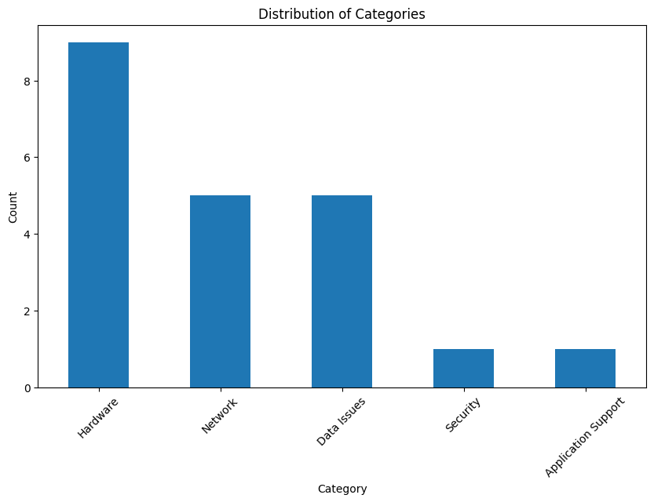

```python
category_counts = final_data['Category'].value_counts()


plt.figure(figsize=(10, 6))
category_counts.plot(kind='bar')
plt.title('Distribution of Categories')
plt.xlabel('Category')
plt.ylabel('Count')
plt.xticks(rotation=45)
plt.show()
```

## **Task 2: Creating Tags**

**Note**: The output of the model should be in a structured format (JSON format).

```python
final_data['Tags'].value_counts()
```

```
Tags
[Data Recovery]                                         2
[Laptop, Startup]                                       1
[Connectivity, Internet, Disconnections, Slow Speed]    1
[Storage Devices]                                       1
[Wi-Fi, Connectivity]                                   1
[Connectivity, Internet]                                1
[Touchpad]                                              1
[Data Recovery, Hardware Damage]                        1
[Hardware Damage]                                       1
[Display]                                               1
[Connectivity, Internet, Wired Connection]              1
[Graphics Card]                                         1
[Data Recovery, External Hard Drive]                    1
[Hardware Malfunction, Blue Screen Error]               1
[Performance, Productivity]                             1
[Account Access, Password Reset]                        1
[Battery]                                               1
[Wi-Fi, Signal Strength]                                1
[Data Loss]                                             1
[Software Compatibility, Data Loss]                     1
Name: count, dtype: int64
```

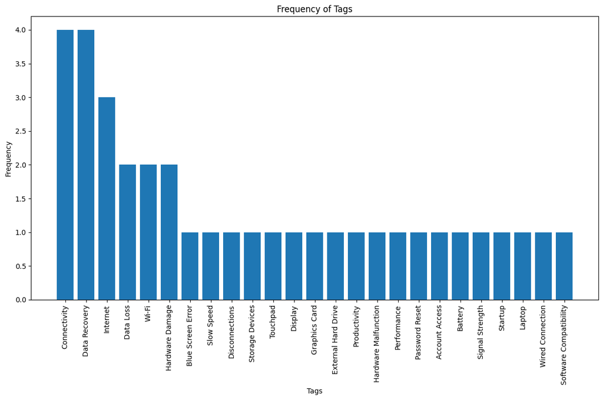

```python
all_tags = [tag for sublist in final_data['Tags'] for tag in sublist]

# Count occurrences of each tag
tag_counts = Counter(all_tags)

# Convert the counter to a DataFrame for plotting
tag_counts_df = pd.DataFrame(tag_counts.items(), columns=['Tag', 'Count']).sort_values(by='Count', ascending=False)

# Creating a bar plot
plt.figure(figsize=(12, 8))
plt.bar(tag_counts_df['Tag'], tag_counts_df['Count'])
plt.title('Frequency of Tags')
plt.xlabel('Tags')
plt.ylabel('Frequency')
plt.xticks(rotation=90)  # Rotate the tags on x-axis to make them readable
plt.tight_layout()  # Adjust layout to make room for the rotated x-axis labels
plt.show()
```

**Observations**

- The LLM performed well in providing appropriate tags to each of the support tickets

## **Task 3: Assigning Priority**

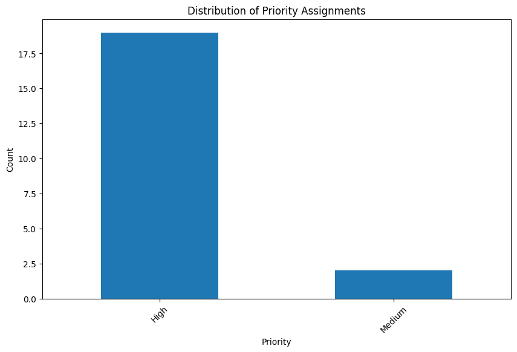

```python
priority_counts = final_data['Priority'].value_counts()


plt.figure(figsize=(10, 6))
priority_counts.plot(kind='bar')
plt.title('Distribution of Priority Assignments')
plt.xlabel('Priority')
plt.ylabel('Count')
plt.xticks(rotation=45)
plt.show()
```

**Observations**

- Regardless of changes made to the prompt, the LLM never prioritizes anything as `Low`. This would require someone to have continuous oversight of the `Medium` assignments
- One suggested change would be `human-in-the-loop` intervention to further refine the outputs in order to develop relative prioritization.

## **Task 4: ETA Review**

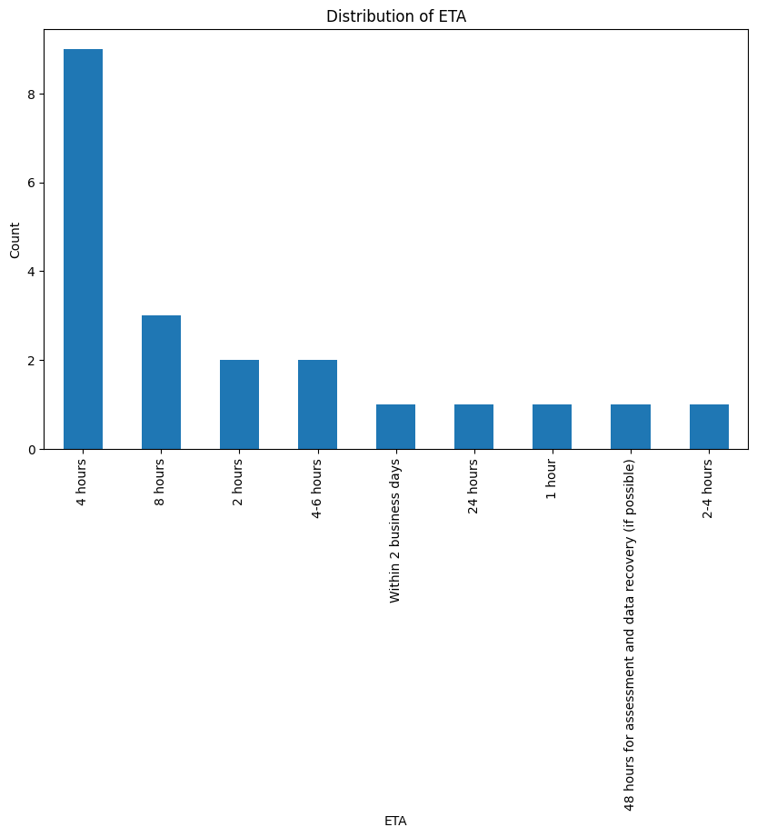

```python
eta_counts = final_data['ETA'].value_counts()


plt.figure(figsize=(10, 6))
eta_counts.plot(kind='bar')
plt.title('Distribution of ETA')
plt.xlabel('ETA')
plt.ylabel('Count')
plt.xticks(rotation=90)
plt.show()
```

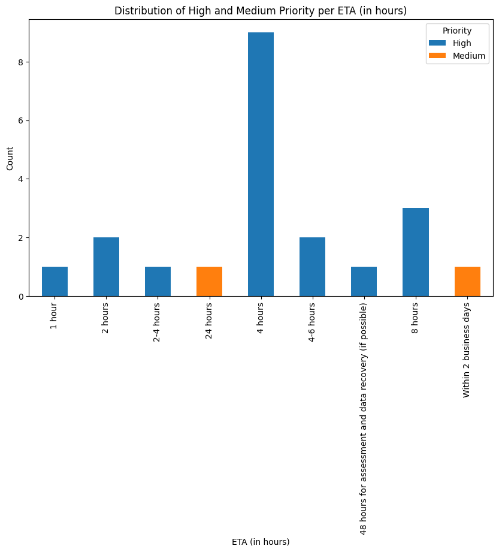

```python
# Filter the data for High and Medium priority
filtered_data = final_data[final_data['Priority'].isin(['High', 'Medium'])]

# Group by ETA and Priority, then count occurrences
grouped_data = filtered_data.groupby(['ETA', 'Priority']).size().unstack(fill_value=0)

# Plot the data
plt.figure(figsize=(10, 6))
grouped_data.plot(kind='bar', stacked=True, ax=plt.gca())
plt.title('Distribution of High and Medium Priority per ETA (in hours)')
plt.xlabel('ETA (in hours)')
plt.ylabel('Count')
plt.xticks(rotation=90)
plt.legend(title='Priority')
plt.show()
```

## **Task 5 - Reviewing Draft Responses**

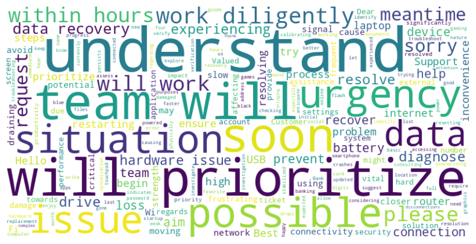

```python
# Combine all draft responses into a single string
text = " ".join(final_data['Draft Response'].dropna().astype(str))

# Generate the word cloud
wordcloud = WordCloud(width=800, height=400, background_color='white').generate(text)

# Display the word cloud using matplotlib
plt.figure(figsize=(10, 5))
plt.imshow(wordcloud, interpolation='bilinear')
plt.axis('off')  # Hide the axes
plt.show()
```

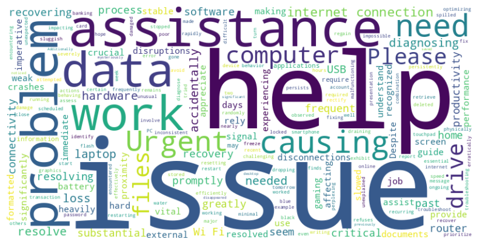

```python
# Combine all draft responses into a single string
text = " ".join(final_data['support_ticket_text'].dropna().astype(str))

# Generate the word cloud
wordcloud = WordCloud(width=800, height=400, background_color='white').generate(text)

# Display the word cloud using matplotlib
plt.figure(figsize=(10, 5))
plt.imshow(wordcloud, interpolation='bilinear')
plt.axis('off')  # Hide the axes
plt.show()
```

#### **Review of High Priority Word Choice**

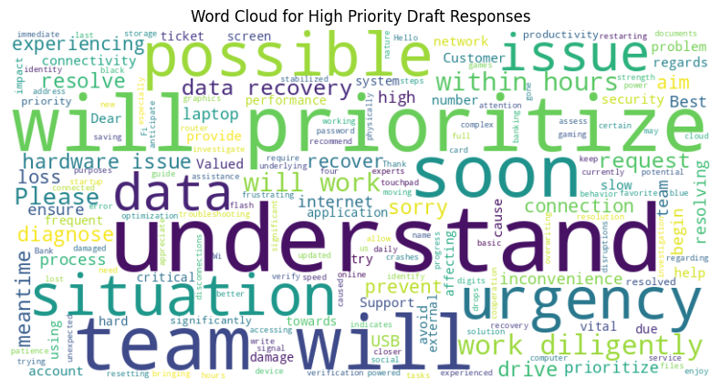

```python
# Filter the DataFrame for High priority responses
high_priority_responses = final_data[final_data['Priority'] == 'High']

# Combine all responses into a single string
combined_text = " ".join(high_priority_responses['Draft Response'].tolist())

# Generate the word cloud
wordcloud = WordCloud(width=800, height=400, background_color='white').generate(combined_text)

# Display the word cloud using matplotlib
plt.figure(figsize=(10, 5))
plt.imshow(wordcloud, interpolation='bilinear')
plt.axis('off')  # Hide the axes
plt.title('Word Cloud for High Priority Draft Responses')
plt.show()
```

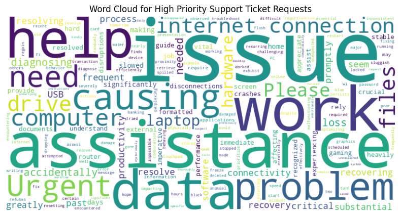

```python
# Filter the DataFrame for High priority responses
high_priority_responses = final_data[final_data['Priority'] == 'High']

# Combine all responses into a single string
combined_text = " ".join(high_priority_responses['support_ticket_text'].tolist())

# Generate the word cloud
wordcloud = WordCloud(width=800, height=400, background_color='white').generate(combined_text)

# Display the word cloud using matplotlib
plt.figure(figsize=(10, 5))
plt.imshow(wordcloud, interpolation='bilinear')
plt.axis('off')  # Hide the axes
plt.title('Word Cloud for High Priority Support Ticket Requests')
plt.show()
```